# Predicting Stroke

### 4.2.3 Predicting the Probability of Stroke Incidence

#### 4.2.3.1 4.1. Estimation

##### 4.2.3.1.1 Logistic Regression

In estimating the model to predict $Stroke$, we initially included all the significant variables: $Age$, $Hypertension$ and $AvgGlucose$ as well as the identified variables that indirectly affect stroke as interaction terms such as the following:

$Stroke = \alpha + \beta_1Age + \beta_2Hypertension + \beta_3AvgGlucose + \beta_4Hypertension*BMI + \beta_5AvgGlucose*BMI + \epsilon_i$ (10)

*Figure 4.4. Estimations of Logistic Model (Interaction Term Included)*

```
##
## Call:
## glm(formula = stroke ~ age + hypertension + avg_glucose_level +
##     hypertension * bmi + avg_glucose_level * bmi, family = "binomial",
##     data = trainData)
##
## Deviance Residuals:
##     Min       1Q   Median       3Q      Max
## -1.0367  -0.3507  -0.2041  -0.1143   3.1437
##
## Coefficients:
##                         Estimate Std. Error z value Pr(>|z|)
## (Intercept)           -5.9760679  1.1896549  -5.023 5.08e-07 ***
## age                    0.0659397  0.0070417   9.364  < 2e-16 ***
## hypertension           1.1557372  0.9263073   1.248    0.212
## avg_glucose_level     -0.0072197  0.0071813  -1.005    0.315
## bmi                   -0.0452844  0.0359987  -1.258    0.208
## hypertension:bmi      -0.0179176  0.0290126  -0.618    0.537
## avg_glucose_level:bmi  0.0003670  0.0002243   1.636    0.102
## ---
## Signif. codes:  0 '***' 0.001 '**' 0.01 '*' 0.05 '.' 0.1 ' ' 1
##
## (Dispersion parameter for binomial family taken to be 1)
##
##     Null deviance: 1098.31  on 2568  degrees of freedom
## Residual deviance:  907.97  on 2562  degrees of freedom
## AIC: 921.97
##
## Number of Fisher Scoring iterations: 7
```

Final Model Output

| term | estimate | std.error | statistic | p.value | sig |
| --- | --- | --- | --- | --- | --- |
| (Intercept) | -5.976 | 1.190 | -5.023 | 0.000 | *** |
| age | 0.066 | 0.007 | 9.364 | 0.000 | *** |
| hypertension | 1.156 | 0.926 | 1.248 | 0.212 |  |
| avg_glucose_level | -0.007 | 0.007 | -1.005 | 0.315 |  |
| bmi | -0.045 | 0.036 | -1.258 | 0.208 |  |
| hypertension:bmi | -0.018 | 0.029 | -0.618 | 0.537 |  |
| avg_glucose_level:bmi | 0.000 | 0.000 | 1.636 | 0.102 |  |

Next, we checked whether multicollinearity exists in eq.10.

VIF for Final Model

|  | x |
| --- | --- |
| age | 1.091 |
| hypertension | 21.988 |
| avg_glucose_level | 24.185 |
| bmi | 7.076 |
| hypertension:bmi | 23.165 |
| avg_glucose_level:bmi | 37.534 |

According to the VIF values, there appears to be extreme multicollinearity within the model as they exceed far beyond the value of $10.0.$ for most of the explanatory variables. Hence, we decided to remove the interaction terms to predict stroke denoted by:

*Model 1* $Stroke = \alpha + \beta_1Age + \beta_2Hypertension + \beta_3AvgGlucose + \epsilon_i$ (11)

*Figure 4.5. Estimations of Logistic Model (Interaction Term Excluded)*

```
##
## Call:
## glm(formula = stroke ~ age + hypertension + avg_glucose_level,
##     family = "binomial", data = trainData)
##
## Deviance Residuals:
##     Min       1Q   Median       3Q      Max
## -1.0210  -0.3541  -0.2069  -0.1167   3.1397
##
## Coefficients:
##                    Estimate Std. Error z value Pr(>|z|)
## (Intercept)       -7.352237   0.475330 -15.468  < 2e-16 ***
## age                0.065779   0.006859   9.590  < 2e-16 ***
## hypertension       0.606486   0.202327   2.998  0.00272 **
## avg_glucose_level  0.004277   0.001502   2.848  0.00440 **
## ---
## Signif. codes:  0 '***' 0.001 '**' 0.01 '*' 0.05 '.' 0.1 ' ' 1
##
## (Dispersion parameter for binomial family taken to be 1)
##
##     Null deviance: 1098.31  on 2568  degrees of freedom
## Residual deviance:  910.71  on 2565  degrees of freedom
## AIC: 918.71
##
## Number of Fisher Scoring iterations: 7
```

Summary of Final Adjusted Model

| term | estimate | std.error | statistic | p.value | sig |
| --- | --- | --- | --- | --- | --- |
| (Intercept) | -7.352 | 0.475 | -15.468 | 0.000 | *** |
| age | 0.066 | 0.007 | 9.590 | 0.000 | *** |
| hypertension | 0.606 | 0.202 | 2.998 | 0.003 | ** |
| avg_glucose_level | 0.004 | 0.002 | 2.848 | 0.004 | ** |

After removing the interaction term, all of our independent variables are significant. We call this *Model 1*. To make sure that there is no multicollinearity present, another VIF will be performed on the revised model (11).

VIF for Final Adjusted Model

|  | x |
| --- | --- |
| age | 1.043 |
| hypertension | 1.053 |
| avg_glucose_level | 1.046 |

[output not shown]

Based on the VIF values, we could see that *Model 1* no longer has multicollinearity as they are all near value of $1.0.$.

#### 4.2.3.2 Regularized Regression

Next, we incorporated the regularization method to retrain our data in order to arrive at our final model that is robust and parsimonious.

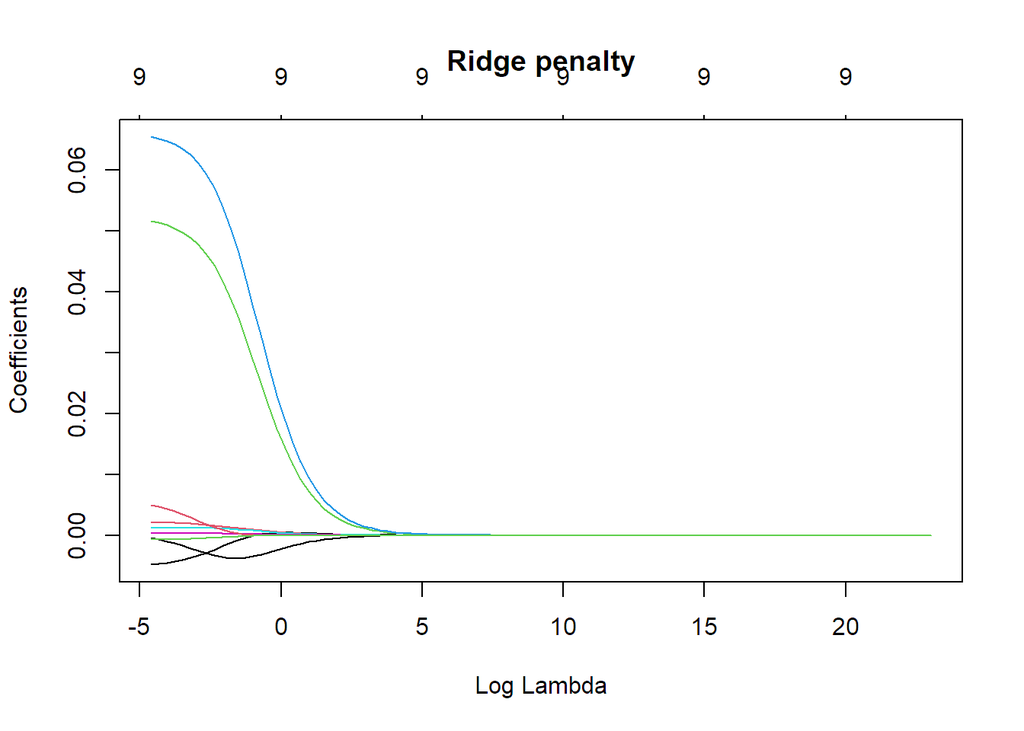

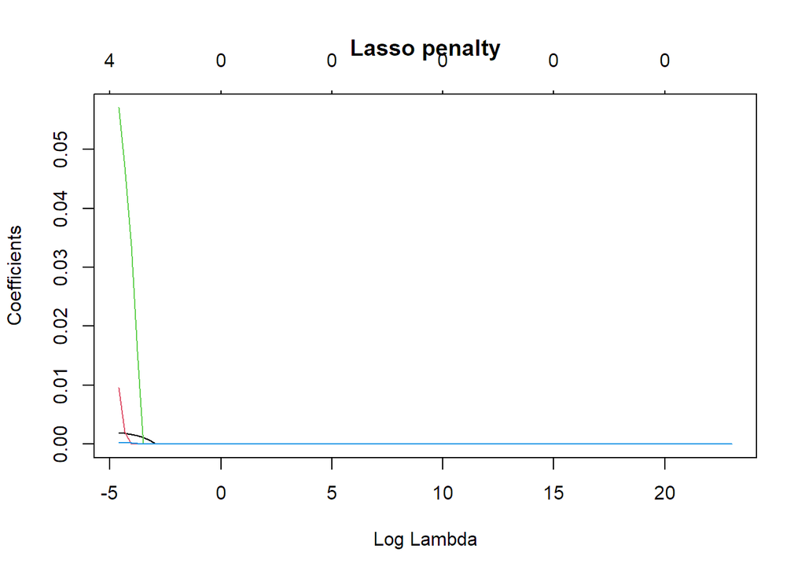

```
##
## Call:  cv.glmnet(x = x[train, ], y = y[train], type.measure = "deviance",      alpha = 0, family = "binomial")
##
## Measure: Binomial Deviance
##
##      Lambda Index Measure     SE Nonzero
## min 0.00527   100  0.3252 0.0194       9
## 1se 0.06500    73  0.3435 0.0173       9
```

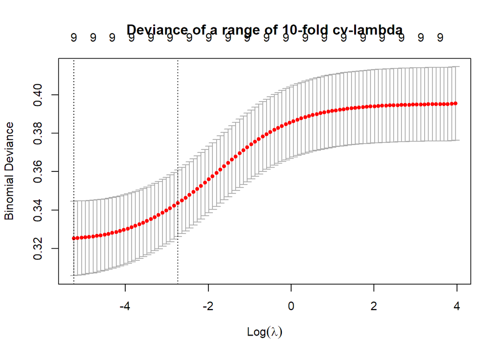

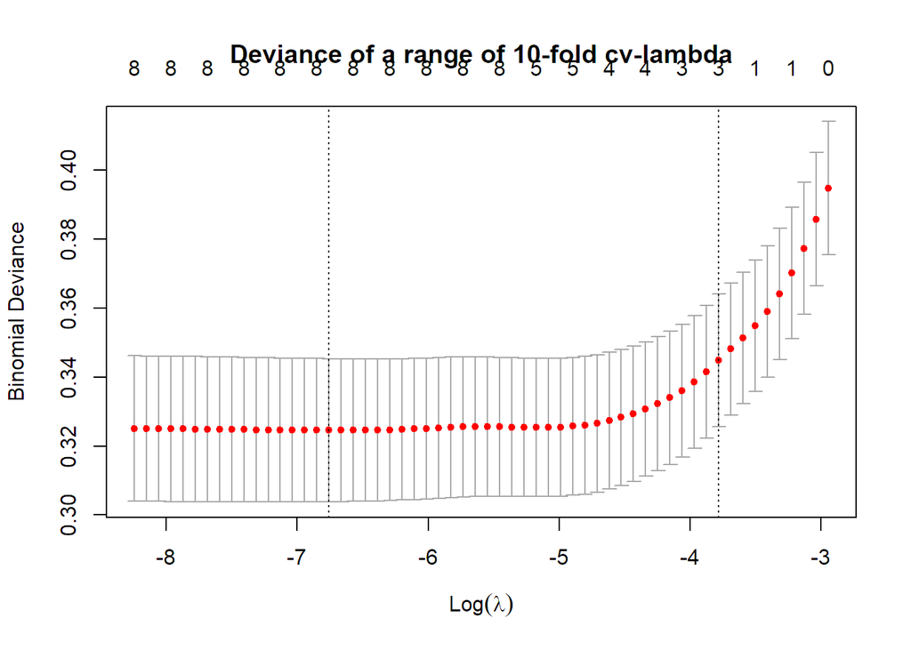

```
##                (Intercept)                 genderMale
##              -8.001200e-02              -5.012258e-03
##                        age               hypertension
##               2.181785e-03               5.199214e-02
##              heart_disease        Residence_typeUrban
##               6.584244e-02               1.258863e-03
##          avg_glucose_level smoking_statusnever smoked
##               3.630275e-04              -8.985631e-05
##       smoking_statussmokes                        bmi
##               5.452347e-03              -7.547436e-04
```

```
##                (Intercept)                 genderMale
##              -0.0709278748               0.0000000000
##                        age               hypertension
##               0.0019611108               0.0294299822
##              heart_disease        Residence_typeUrban
##               0.0371322574               0.0000000000
##          avg_glucose_level smoking_statusnever smoked
##               0.0002061679               0.0000000000
##       smoking_statussmokes                        bmi
##               0.0000000000               0.0000000000
```

```
##       (Intercept)               age      hypertension     heart_disease
##     -0.0709278748      0.0019611108      0.0294299822      0.0371322574
## avg_glucose_level
##      0.0002061679
```